# Chapter 5

Parash Upreti

July 11, 2016

## CHAPTER 5 EXAMPLES IN R

Euclidean distance function

```r
euclidean=function(x1,x2){
  return(sqrt((x1-x2)%*%(x1-x2)))
}
```

Test example

```r
euclidean(c(1,0),c(0,1))
```

```
##          [,1]
## [1,] 1.414214
```

```r
#More examples
x1=c(90,1300)
x2=c(85,1200)
euclidean(x1,x2)
```

```
##          [,1]
## [1,] 100.1249
```

```r
x1=c(70,950)
x2=c(40,880)
euclidean(x1,x2)
```

```
##          [,1]
## [1,] 76.15773
```

```r
xbar=c(67.04,978.21)
s=c(18.61,132.35)

x1=c(90,1300)
x2=c(85,1200)
z1=(x1-xbar)/s
z2=(x2-xbar)/s
euclidean(z1,z2)
```

```
##           [,1]
## [1,] 0.8019193
```

```r
x1=c(70,950)
x2=c(40,880)
z1=(x1-xbar)/s
z2=(x2-xbar)/s
euclidean(z1,z2)
```

```
##          [,1]
## [1,] 1.696584
```

### Standardizing iris

```r
x=iris[,1:4]
xbar=apply(x,2,mean)
xbarMatrix=cbind(rep(1,150))%*%xbar
s=apply(x,2,sd)
sMatrix=cbind(rep(1,150))%*%s

z=(x-xbarMatrix)/sMatrix
apply(z,2,mean)
```

```
##  Sepal.Length   Sepal.Width  Petal.Length   Petal.Width
## -4.484318e-16  2.034094e-16 -2.895326e-17 -2.989362e-17
```

```r
apply(z,2,sd)
```

```
## Sepal.Length  Sepal.Width Petal.Length  Petal.Width
##            1            1            1            1
```

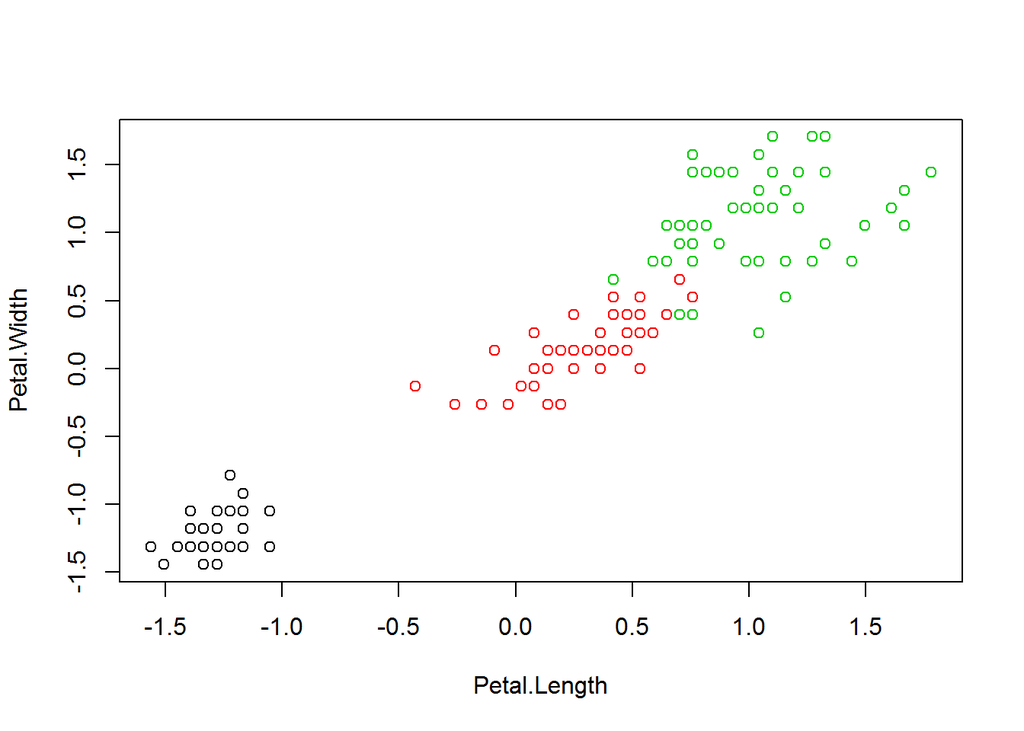

```r
plot(z[,3:4],col=iris$Species)
```

Split iris into 70% training and 30% test data.

```r
set.seed=5364
train=sample(nrow(z),nrow(z)*.7)

z[train,]    #This is the training data
```

```
##     Sepal.Length Sepal.Width Petal.Length   Petal.Width
## 59    0.91377565 -0.36096697   0.47697323  0.1320672944
## 19   -0.17309407  1.70388647  -1.16580868 -1.1798594716
## 123   2.24217198 -0.59039513   1.66657392  1.0504160307
## 35   -1.13920048  0.09788935  -1.27910398 -1.3110521482
## 107  -1.13920048 -1.27867961   0.42032558  0.6568380009
## 103   1.51759216 -0.13153881   1.21339271  1.1816087073
## 27   -1.01843718  0.78617383  -1.22245633 -1.0486667950
## 145   1.03453895  0.55674567   1.10009740  1.7063794137
## 34   -0.41462067  2.62159911  -1.33575163 -1.3110521482
## 121   1.27606556  0.32731751   1.10009740  1.4439940605
## 5    -1.01843718  1.24503015  -1.33575163 -1.3110521482
## 39   -1.74301699 -0.13153881  -1.39239929 -1.3110521482
## 6    -0.53538397  1.93331463  -1.16580868 -1.0486667950
## 47   -0.89767388  1.70388647  -1.22245633 -1.3110521482
```

[output cut: 91 more lines]

```r
z[-train,]   #This is the test data
```

```
##     Sepal.Length Sepal.Width Petal.Length   Petal.Width
## 2    -1.13920048 -0.13153881  -1.33575163 -1.3110521482
## 4    -1.50149039  0.09788935  -1.27910398 -1.3110521482
## 9    -1.74301699 -0.36096697  -1.33575163 -1.3110521482
## 11   -0.53538397  1.47445831  -1.27910398 -1.3110521482
## 17   -0.53538397  1.93331463  -1.39239929 -1.0486667950
## 18   -0.89767388  1.01560199  -1.33575163 -1.1798594716
## 22   -0.89767388  1.47445831  -1.27910398 -1.0486667950
## 23   -1.50149039  1.24503015  -1.56234224 -1.3110521482
## 25   -1.25996379  0.78617383  -1.05251337 -1.3110521482
## 28   -0.77691058  1.01560199  -1.27910398 -1.3110521482
## 30   -1.38072709  0.32731751  -1.22245633 -1.3110521482
## 32   -0.53538397  0.78617383  -1.27910398 -1.0486667950
## 36   -1.01843718  0.32731751  -1.44904694 -1.3110521482
## 41   -1.01843718  1.01560199  -1.39239929 -1.1798594716
```

[output cut: 31 more lines]

```r
#confmatrix
confmatrix=function(y,predy){
  matrix=table(y,predy)
  accuracy=sum(diag(matrix))/sum(matrix)
  return(list(matrix=matrix,accuracy=accuracy,error=1-accuracy))
}
```

# KNN

The class package and knn function

```r
library(class)
Species=iris$Species
predSpecies=knn(train=z[train,],test=z[-train,],cl=Species[train],k=3)

confmatrix(Species[-train],predSpecies)
```

```
## $matrix
##             predy
## y            setosa versicolor virginica
##   setosa         15          0         0
##   versicolor      0         16         1
##   virginica       0          0        13
##
## $accuracy
## [1] 0.9777778
##
## $error
## [1] 0.02222222
```

Leave-one-out CV for knn

```r
predSpecies=knn.cv(train=z,cl=Species,k=3)
confmatrix(Species,predSpecies)
```

```
## $matrix
##             predy
## y            setosa versicolor virginica
##   setosa         49          1         0
##   versicolor      0         47         3
##   virginica       0          4        46
##
## $accuracy
## [1] 0.9466667
##
## $error
## [1] 0.05333333
```

Optimizing k with cross validation

```r
accvect=1:10

for(k in 1:10){
  predSpecies=knn.cv(train=z,cl=Species,k=k)
  accvect[k]=confmatrix(Species,predSpecies)$accuracy
}

which.max(accvect)
```

```
## [1] 7
```

```r
#knn with k = 7
Species=iris$Species
predSpecies=knn(train=z[train,],test=z[-train,],cl=Species[train],k=7)

confmatrix(Species[-train],predSpecies)
```

```
## $matrix
##             predy
## y            setosa versicolor virginica
##   setosa         15          0         0
##   versicolor      0         16         1
##   virginica       0          0        13
##
## $accuracy
## [1] 0.9777778
##
## $error
## [1] 0.02222222
```

### fgl Data

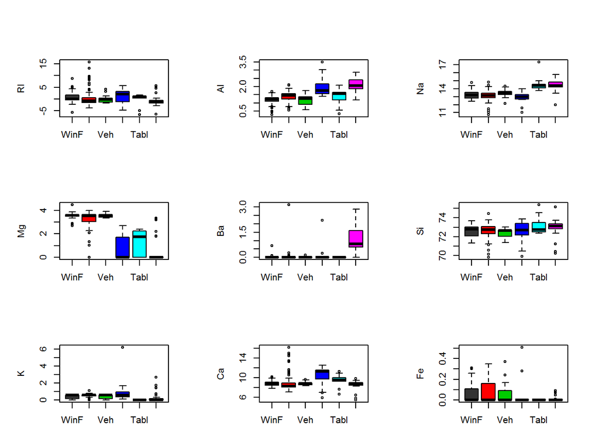

```r
library(MASS) ## a library of example data sets
data(fgl) ## loads the data into R; see help(fgl)

par(mfrow=c(3,3),mai=c(.3,.7,.7,.36))
plot(RI ~ type, data=fgl, col=c(grey(.2),2:6))
plot(Al ~ type, data=fgl, col=c(grey(.2),2:6))
plot(Na ~ type, data=fgl, col=c(grey(.2),2:6))
plot(Mg ~ type, data=fgl, col=c(grey(.2),2:6))
plot(Ba ~ type, data=fgl, col=c(grey(.2),2:6))
plot(Si ~ type, data=fgl, col=c(grey(.2),2:6))
plot(K ~ type, data=fgl, col=c(grey(.2),2:6))
plot(Ca ~ type, data=fgl, col=c(grey(.2),2:6))
plot(Fe ~ type, data=fgl, col=c(grey(.2),2:6))
```

Standardize function

Standardize accepts a matrix of quantitative variables x and returns the corresponding standardized matrix z whose columns have mean 0 and st dev 1.There is a built in function in R called `scale` which achieves the same as well.

```r
standardize=function(x){
  xbar=apply(x,2,mean)
  xbarMatrix=cbind(rep(1,nrow(x)))%*%xbar
  s=apply(x,2,sd)
  sMatrix=cbind(rep(1,nrow(x)))%*%s

  z=(x-xbarMatrix)/sMatrix
  return(z)
}
```

knn method from last time

```r
#knn.cv
x=fgl[,1:9]
z=standardize(x)
y=fgl[,10]

set.seed(1019)
accvect=1:15

library(class)
for(k in 1:15){
  predy=knn.cv(train=z,cl=y,k=k)
  accvect[k]=confmatrix(y,predy)$accuracy
}

which.max(accvect)
```

```
## [1] 3
```

knn with training and test data

```r
train=sample(nrow(z),round(nrow(z)*.7,0))

predy=knn(train=z[train,],test=z[-train,],cl=y[train],k=3)

confmatrix(y[-train],predy)
```

```
## $matrix
##        predy
## y       WinF WinNF Veh Con Tabl Head
##   WinF    10     7   2   0    0    0
##   WinNF    1    18   1   0    1    0
##   Veh      2     0   2   0    0    0
##   Con      0     1   0   3    0    0
##   Tabl     0     1   0   0    1    1
##   Head     1     0   1   0    0   11
##
## $accuracy
## [1] 0.703125
##
## $error
## [1] 0.296875
```

kknn approach

```r
library(kknn)
```

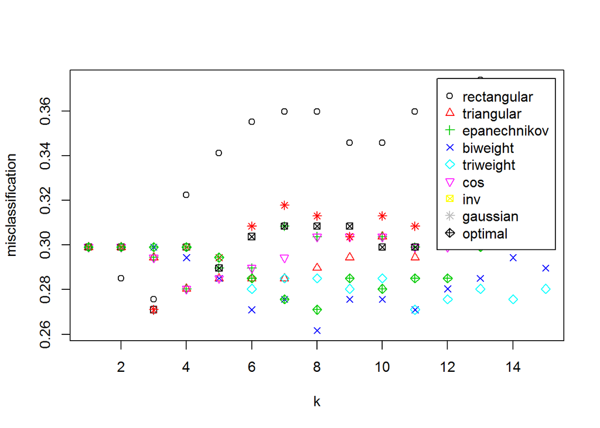

```r
fit.glass = train.kknn(type ~ ., data=fgl, kmax = 15,
                       kernel =c("rectangular","triangular", "epanechnikov",  "biweight",
                                 "triweight","cos","inv", "gaussian" ,"optimal"),
                       distance = 2)
plot(fit.glass)
```

```r
fit.glass$MISCLASS
```

```
##    rectangular triangular epanechnikov  biweight triweight       cos
## 1    0.2990654  0.2990654    0.2990654 0.2990654 0.2990654 0.2990654
## 2    0.2850467  0.2990654    0.2990654 0.2990654 0.2990654 0.2990654
## 3    0.2757009  0.2943925    0.2943925 0.2990654 0.2990654 0.2943925
## 4    0.3224299  0.2803738    0.2803738 0.2943925 0.2990654 0.2803738
## 5    0.3411215  0.2850467    0.2897196 0.2850467 0.2943925 0.2850467
## 6    0.3551402  0.2850467    0.2897196 0.2710280 0.2803738 0.2897196
## 7    0.3598131  0.2850467    0.3084112 0.2757009 0.2850467 0.2943925
## 8    0.3598131  0.2897196    0.3037383 0.2616822 0.2850467 0.3037383
## 9    0.3457944  0.2943925    0.3037383 0.2757009 0.2803738 0.3037383
## 10   0.3457944  0.3037383    0.3037383 0.2757009 0.2850467 0.3037383
## 11   0.3598131  0.2943925    0.2990654 0.2710280 0.2710280 0.2990654
## 12   0.3411215  0.2990654    0.3037383 0.2803738 0.2757009 0.2990654
## 13   0.3738318  0.2990654    0.3084112 0.2850467 0.2803738 0.3037383
## 14   0.3504673  0.3037383    0.3084112 0.2943925 0.2757009 0.3084112
```

[output cut: 17 more lines]

```r
predy2=(kknn(type~.,train=fgl[train,],test=fgl[-train,],
             k=3,kernel="rectangular",distance=2))$fitted.values

confmatrix(y[-train],predy2)
```

```
## $matrix
##        predy
## y       WinF WinNF Veh Con Tabl Head
##   WinF    10     7   2   0    0    0
##   WinNF    1    19   1   0    0    0
##   Veh      3     0   1   0    0    0
##   Con      0     1   0   3    0    0
##   Tabl     0     1   0   0    1    1
##   Head     1     0   0   0    0   12
##
## $accuracy
## [1] 0.71875
##
## $error
## [1] 0.28125
```

```r
fit.glass$best.parameters
```

```
## $kernel
## [1] "biweight"
##
## $k
## [1] 8
```

```r
predy3=(kknn(type~.,train=fgl[train,],test=fgl[-train,],
             k=8,kernel="biweight",distance=2))$fitted.values
confmatrix(y[-train],predy3)
```

```
## $matrix
##        predy
## y       WinF WinNF Veh Con Tabl Head
##   WinF    12     7   0   0    0    0
##   WinNF    1    18   2   0    0    0
##   Veh      3     0   1   0    0    0
##   Con      0     1   0   3    0    0
##   Tabl     0     1   0   0    2    0
##   Head     1     0   0   0    0   12
##
## $accuracy
## [1] 0.75
##
## $error
## [1] 0.25
```

# NAIVE BAYES CLASSIFICATION

HouseVotes84 dataset

```r
library(mlbench)
data(HouseVotes84)
```

Finding prior distribution

```r
library(e1071)

model = naiveBayes(Class ~ ., data = HouseVotes84)
model
```

```
##
## Naive Bayes Classifier for Discrete Predictors
##
## Call:
## naiveBayes.default(x = X, y = Y, laplace = laplace)
##
## A-priori probabilities:
## Y
##   democrat republican
##  0.6137931  0.3862069
##
## Conditional probabilities:
##             V1
## Y                    n         y
##   democrat   0.3953488 0.6046512
##   republican 0.8121212 0.1878788
##
##             V2
## Y                    n         y
##   democrat   0.4979079 0.5020921
##   republican 0.4932432 0.5067568
##
##             V3
## Y                    n         y
##   democrat   0.1115385 0.8884615
##   republican 0.8658537 0.1341463
##
##             V4
## Y                     n          y
##   democrat   0.94594595 0.05405405
##   republican 0.01212121 0.98787879
##
##             V5
## Y                     n          y
##   democrat   0.78431373 0.21568627
##   republican 0.04848485 0.95151515
##
##             V6
## Y                    n         y
##   democrat   0.5232558 0.4767442
```

[output cut: 36 more lines]

```
##
##             V14
## Y                     n          y
##   democrat   0.64980545 0.35019455
##   republican 0.01863354 0.98136646
##
##             V15
## Y                     n          y
##   democrat   0.36254980 0.63745020
##   republican 0.91025641 0.08974359
##
##             V16
## Y                     n          y
##   democrat   0.06486486 0.93513514
##   republican 0.34246575 0.65753425
```

```r
model$apriori
```

```
## Y
##   democrat republican
##        267        168
```

```r
table(HouseVotes84$Class)
```

```
##
##   democrat republican
##        267        168
```

```r
model$apriori/(sum(model$apriori))
```

```
## Y
##   democrat republican
##  0.6137931  0.3862069
```

Conditional probabilities

```r
model$tables
```

```
## $V1
##             V1
## Y                    n         y
##   democrat   0.3953488 0.6046512
##   republican 0.8121212 0.1878788
##
## $V2
##             V2
## Y                    n         y
##   democrat   0.4979079 0.5020921
##   republican 0.4932432 0.5067568
##
## $V3
##             V3
## Y                    n         y
##   democrat   0.1115385 0.8884615
##   republican 0.8658537 0.1341463
##
## $V4
##             V4
## Y                     n          y
##   democrat   0.94594595 0.05405405
##   republican 0.01212121 0.98787879
##
## $V5
##             V5
## Y                     n          y
##   democrat   0.78431373 0.21568627
##   republican 0.04848485 0.95151515
##
## $V6
##             V6
## Y                    n         y
##   democrat   0.5232558 0.4767442
##   republican 0.1024096 0.8975904
##
## $V7
##             V7
## Y                    n         y
##   democrat   0.2277992 0.7722008
```

[output cut: 40 more lines]

```
## Y                     n          y
##   democrat   0.64980545 0.35019455
##   republican 0.01863354 0.98136646
##
## $V15
##             V15
## Y                     n          y
##   democrat   0.36254980 0.63745020
##   republican 0.91025641 0.08974359
##
## $V16
##             V16
## Y                     n          y
##   democrat   0.06486486 0.93513514
##   republican 0.34246575 0.65753425
```

```r
(model$tables)$V8
```

```
##             V8
## Y                    n         y
##   democrat   0.1711027 0.8288973
##   republican 0.8471338 0.1528662
```

```r
table(HouseVotes84$Class,HouseVotes84$V8)
```

```
##
##                n   y
##   democrat    45 218
##   republican 133  24
```

```r
45/(45+218)
```

```
## [1] 0.1711027
```

```r
218/(45+218)
```

```
## [1] 0.8288973
```

```r
133/(133+24)
```

```
## [1] 0.8471338
```

```r
24/(133+24)
```

```
## [1] 0.1528662
```

Posterior probabilities

```r
predict(model,newdata=HouseVotes84[1,],type="raw")
```

```
##          democrat republican
## [1,] 1.029209e-07  0.9999999
```

```r
predict(model,newdata=HouseVotes84[1,],type="class")
```

```
## [1] republican
## Levels: democrat republican
```

```r
predict(model,newdata=HouseVotes84[1,])
```

```
## [1] republican
## Levels: democrat republican
```

Training and test data

```r
train=sample(nrow(HouseVotes84),round(.7*nrow(HouseVotes84),0))

model=naiveBayes(Class ~ ., data = HouseVotes84[train,])
predClass=predict(model,newdata=HouseVotes84[-train,])

confmatrix(HouseVotes84$Class[-train],predClass)
```

```
## $matrix
##             predy
## y            democrat republican
##   democrat         70         11
##   republican        3         47
##
## $accuracy
## [1] 0.8931298
##
## $error
## [1] 0.1068702
```

Matrix of posterior probabilities

```r
predict(model,newdata=HouseVotes84[-train,],type="raw")
```

```
##            democrat   republican
##   [1,] 6.029500e-06 9.999940e-01
##   [2,] 1.000000e+00 1.456598e-09
##   [3,] 8.291306e-08 9.999999e-01
##   [4,] 1.000000e+00 1.326992e-10
##   [5,] 4.994278e-08 1.000000e+00
##   [6,] 1.000000e+00 1.592285e-09
##   [7,] 1.000000e+00 9.685592e-12
##   [8,] 2.833364e-02 9.716664e-01
##   [9,] 1.483838e-05 9.999852e-01
##  [10,] 1.000000e+00 3.297434e-11
##  [11,] 1.000000e+00 1.227139e-10
##  [12,] 1.000000e+00 1.049424e-11
##  [13,] 1.000000e+00 2.222875e-11
##  [14,] 4.272182e-08 1.000000e+00
```

[output cut: 117 more lines]

Quantitative Predictors

```r
attach(iris)
model=naiveBayes(Species~.,data=iris)
model
```

```
##
## Naive Bayes Classifier for Discrete Predictors
##
## Call:
## naiveBayes.default(x = X, y = Y, laplace = laplace)
##
## A-priori probabilities:
## Y
##     setosa versicolor  virginica
##  0.3333333  0.3333333  0.3333333
##
## Conditional probabilities:
##             Sepal.Length
## Y             [,1]      [,2]
##   setosa     5.006 0.3524897
##   versicolor 5.936 0.5161711
##   virginica  6.588 0.6358796
##
##             Sepal.Width
## Y             [,1]      [,2]
##   setosa     3.428 0.3790644
##   versicolor 2.770 0.3137983
##   virginica  2.974 0.3224966
##
##             Petal.Length
## Y             [,1]      [,2]
##   setosa     1.462 0.1736640
##   versicolor 4.260 0.4699110
##   virginica  5.552 0.5518947
##
##             Petal.Width
## Y             [,1]      [,2]
##   setosa     0.246 0.1053856
##   versicolor 1.326 0.1977527
##   virginica  2.026 0.2746501
```

```r
mean(Petal.Length[Species=="setosa"])
```

```
## [1] 1.462
```

```r
sd(Petal.Length[Species=="setosa"])
```

```
## [1] 0.173664
```

Normality for iris data

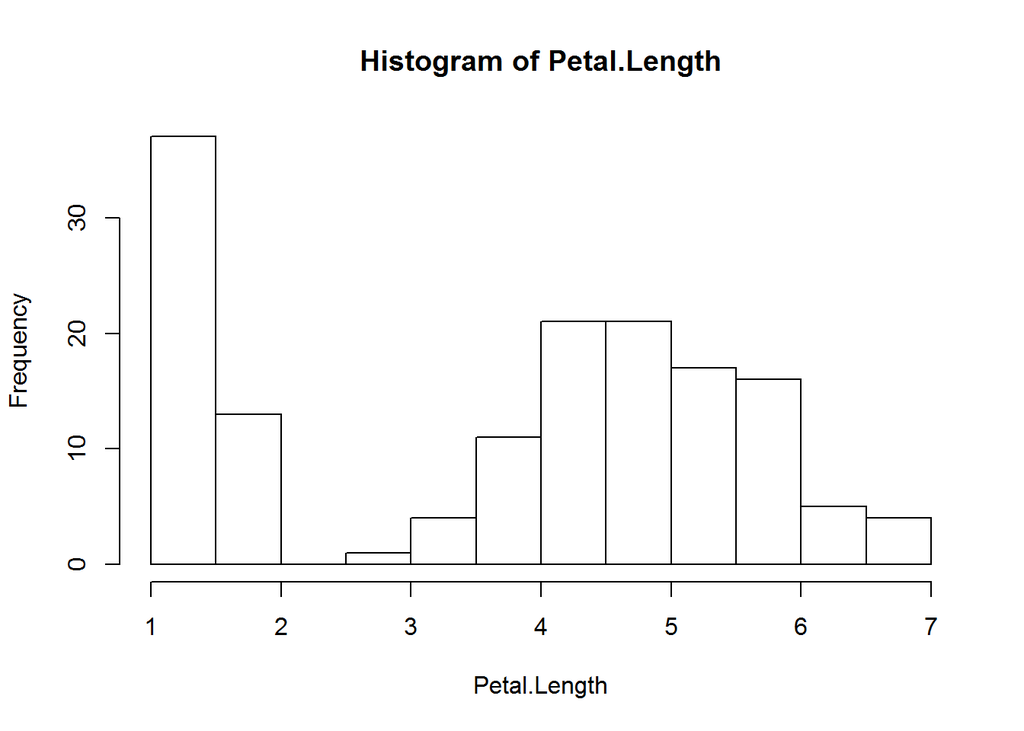

```r
hist(Petal.Length)
```

```r
shapiro.test(Petal.Length)
```

```
##
##  Shapiro-Wilk normality test
##
## data:  Petal.Length
## W = 0.87627, p-value = 7.412e-10
```

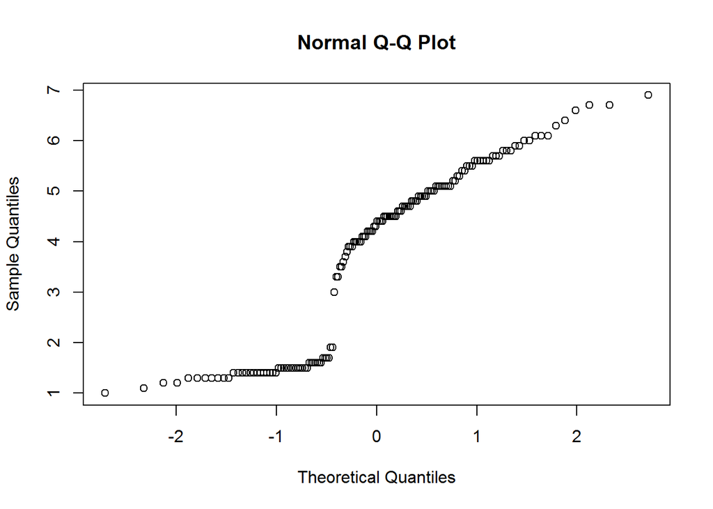

```r
qqnorm(Petal.Length)
```

stratify by species

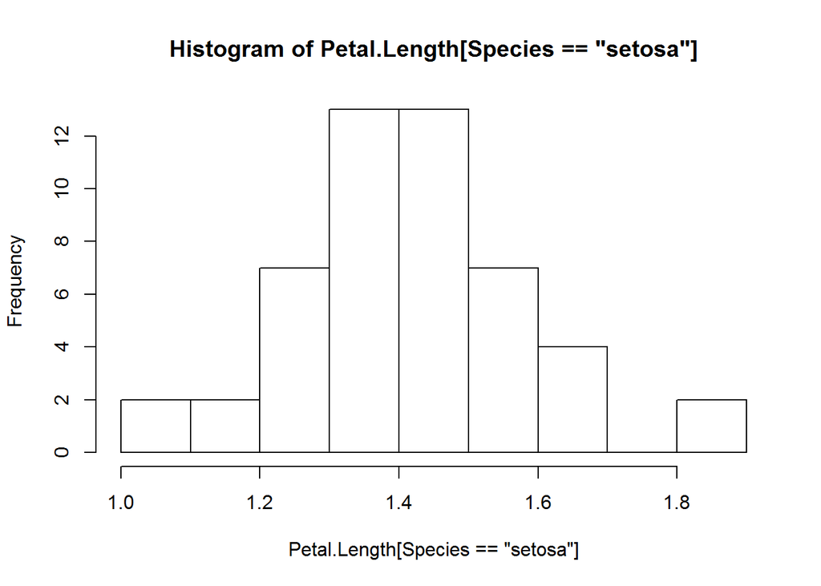

```r
hist(Petal.Length[Species=="setosa"])
```

```r
shapiro.test(Petal.Length[Species=="setosa"])
```

```
##
##  Shapiro-Wilk normality test
##
## data:  Petal.Length[Species == "setosa"]
## W = 0.95498, p-value = 0.05481
```

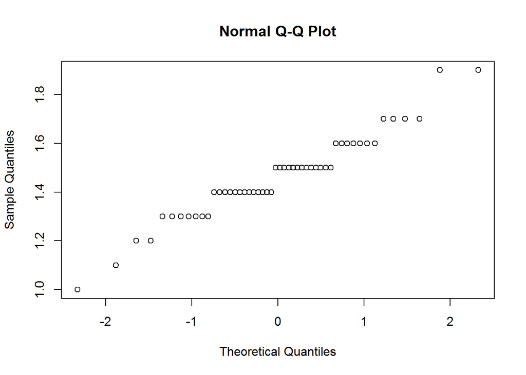

```r
qqnorm(Petal.Length[Species=="setosa"])
```

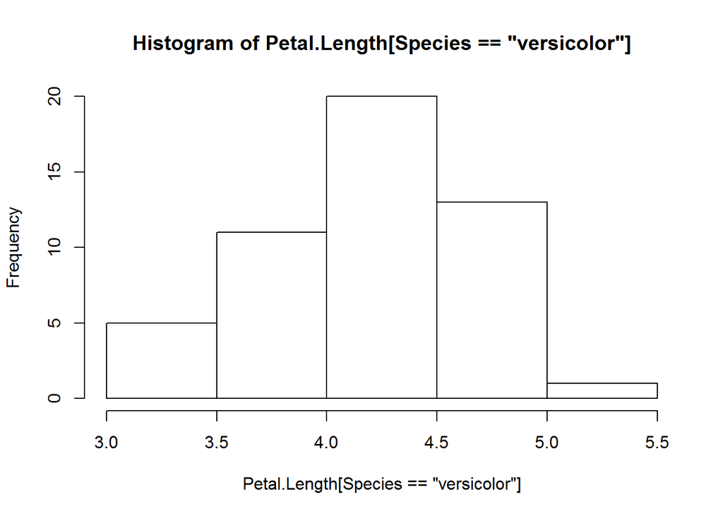

```r
hist(Petal.Length[Species=="versicolor"])
```

```r
shapiro.test(Petal.Length[Species=="versicolor"])
```

```
##
##  Shapiro-Wilk normality test
##
## data:  Petal.Length[Species == "versicolor"]
## W = 0.966, p-value = 0.1585
```

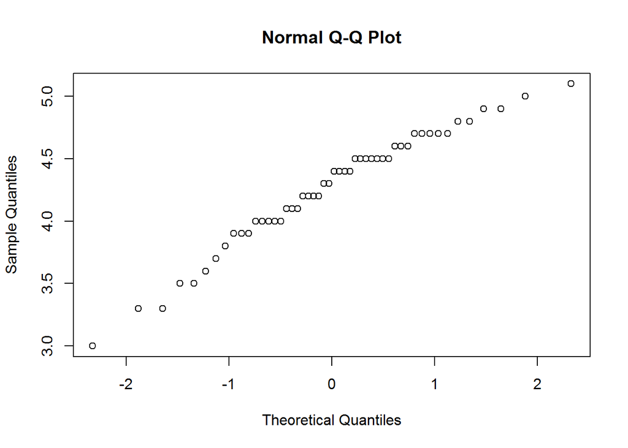

```r
qqnorm(Petal.Length[Species=="versicolor"])
```

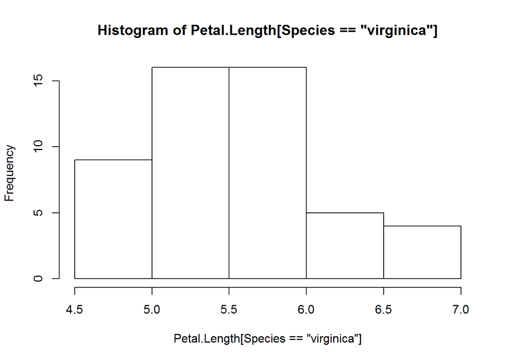

```r
hist(Petal.Length[Species=="virginica"])
```

```r
shapiro.test(Petal.Length[Species=="virginica"])
```

```
##
##  Shapiro-Wilk normality test
##
## data:  Petal.Length[Species == "virginica"]
## W = 0.96219, p-value = 0.1098
```

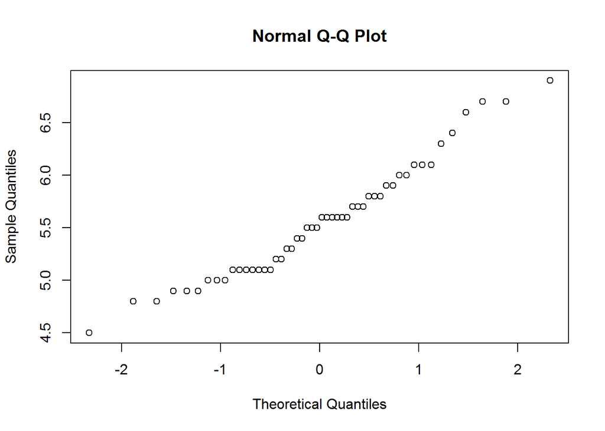

```r
qqnorm(Petal.Length[Species=="virginica"])
```

```r
for(j in 1:4){
  for(spec in levels(Species)){
    vect=iris[,j]
    print(shapiro.test(vect[Species==spec]))
  }
}
```

```
##
##  Shapiro-Wilk normality test
##
## data:  vect[Species == spec]
## W = 0.9777, p-value = 0.4595
##
##
##  Shapiro-Wilk normality test
##
## data:  vect[Species == spec]
## W = 0.97784, p-value = 0.4647
##
##
##  Shapiro-Wilk normality test
##
## data:  vect[Species == spec]
## W = 0.97118, p-value = 0.2583
##
##
##  Shapiro-Wilk normality test
##
## data:  vect[Species == spec]
## W = 0.97172, p-value = 0.2715
##
##
##  Shapiro-Wilk normality test
##
## data:  vect[Species == spec]
## W = 0.97413, p-value = 0.338
##
##
##  Shapiro-Wilk normality test
##
## data:  vect[Species == spec]
## W = 0.96739, p-value = 0.1809
##
##
##  Shapiro-Wilk normality test
##
## data:  vect[Species == spec]
```

[output cut: 16 more lines]

```
##
## data:  vect[Species == spec]
## W = 0.79976, p-value = 8.659e-07
##
##
##  Shapiro-Wilk normality test
##
## data:  vect[Species == spec]
## W = 0.94763, p-value = 0.02728
##
##
##  Shapiro-Wilk normality test
##
## data:  vect[Species == spec]
## W = 0.95977, p-value = 0.08695
```

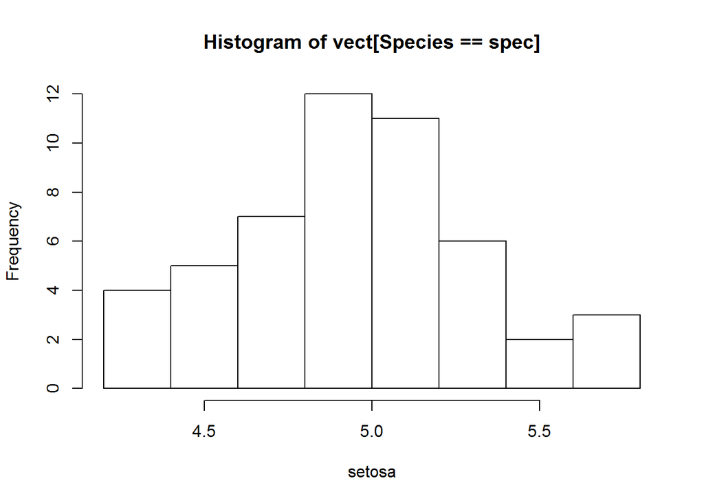

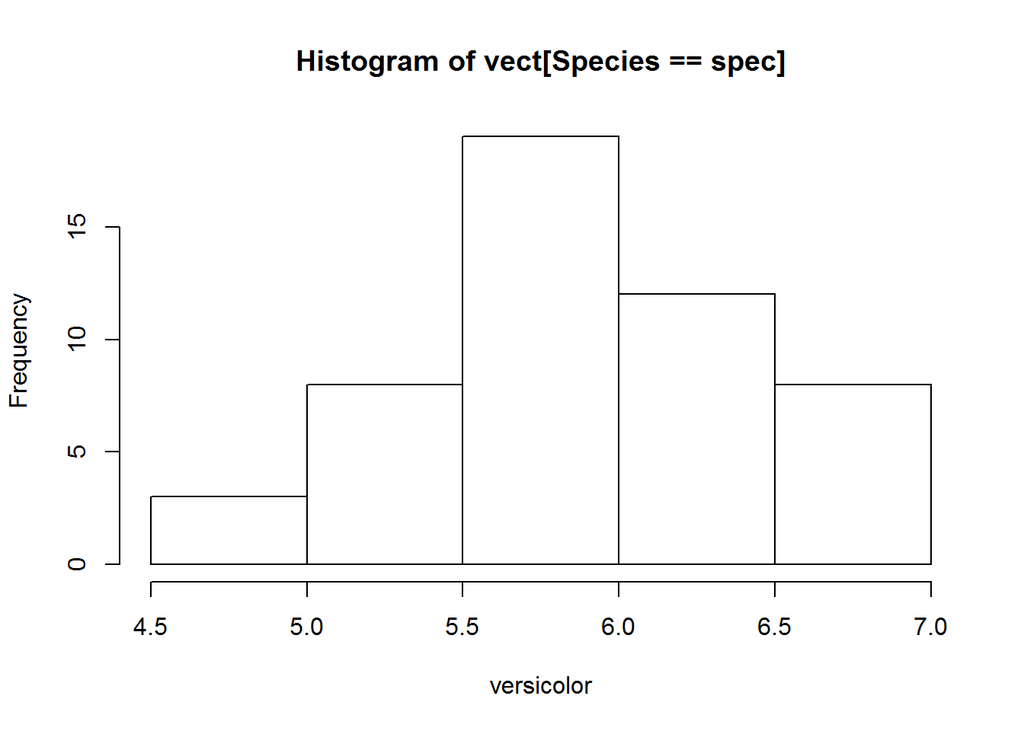

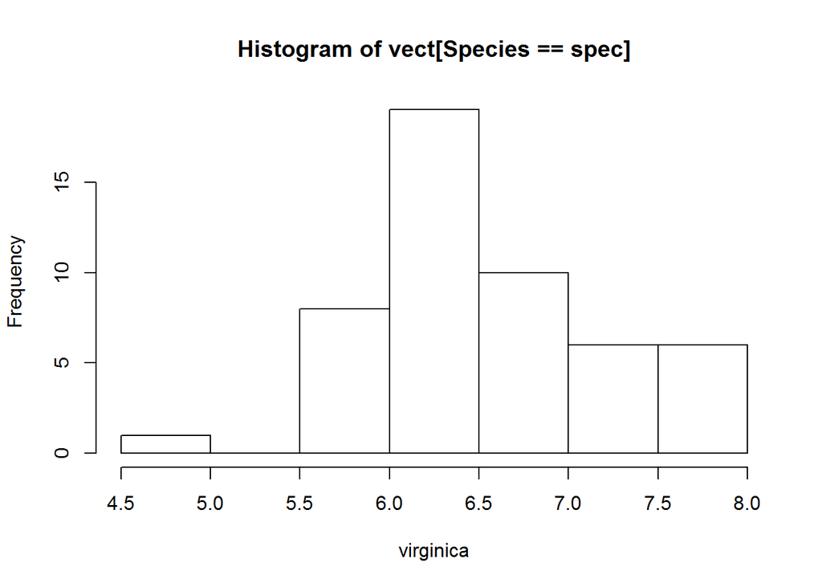

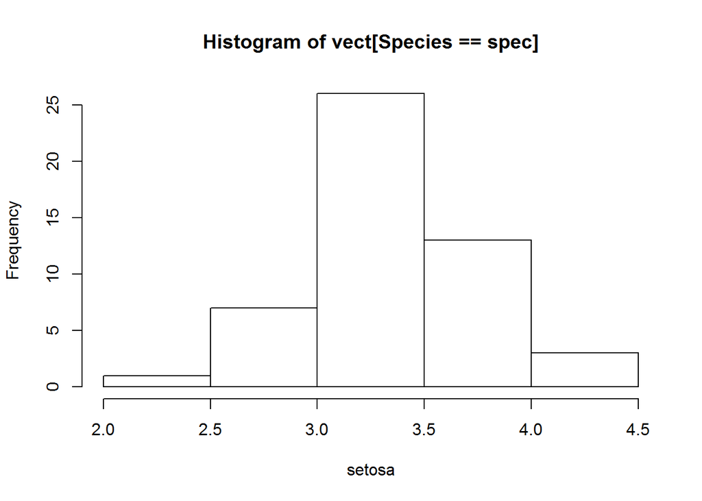

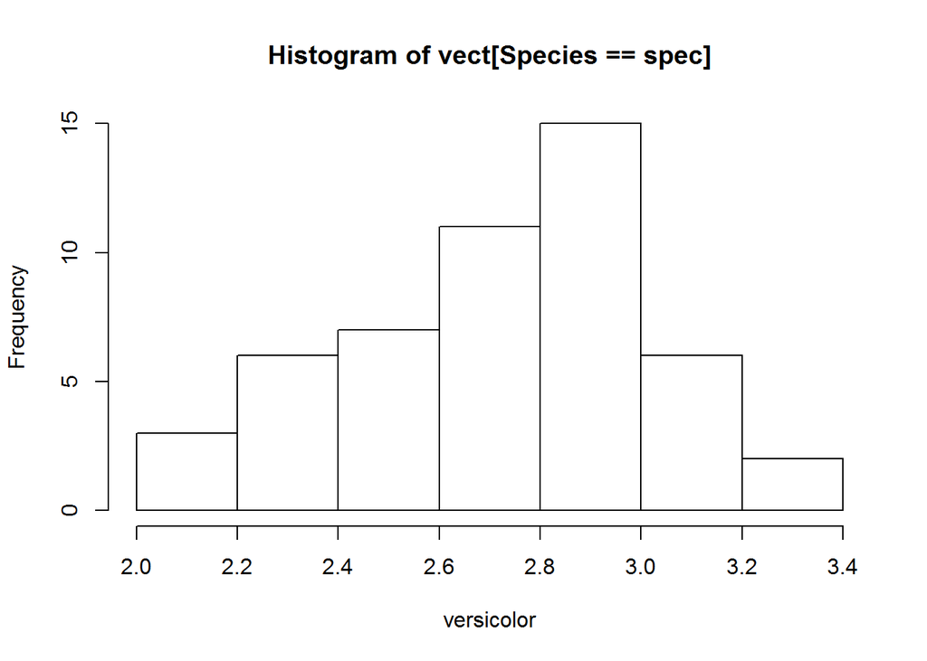

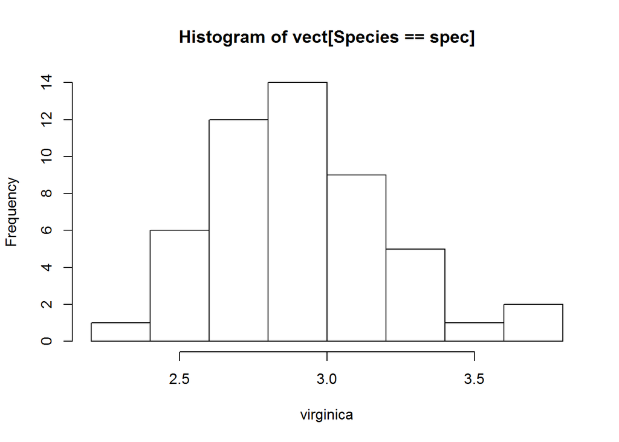

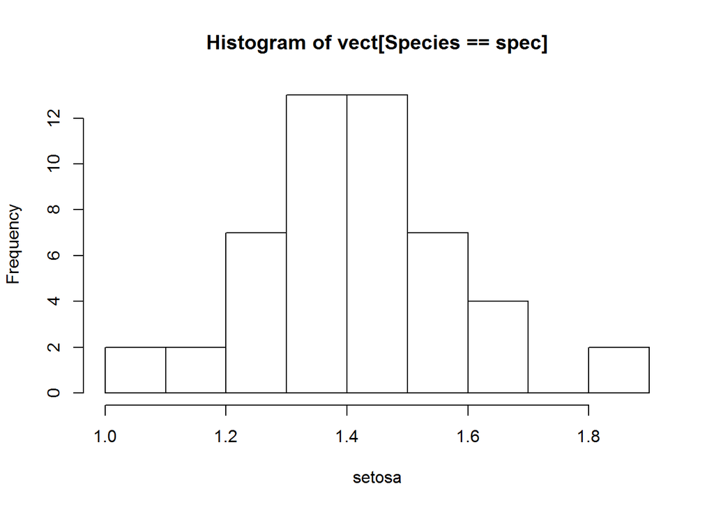

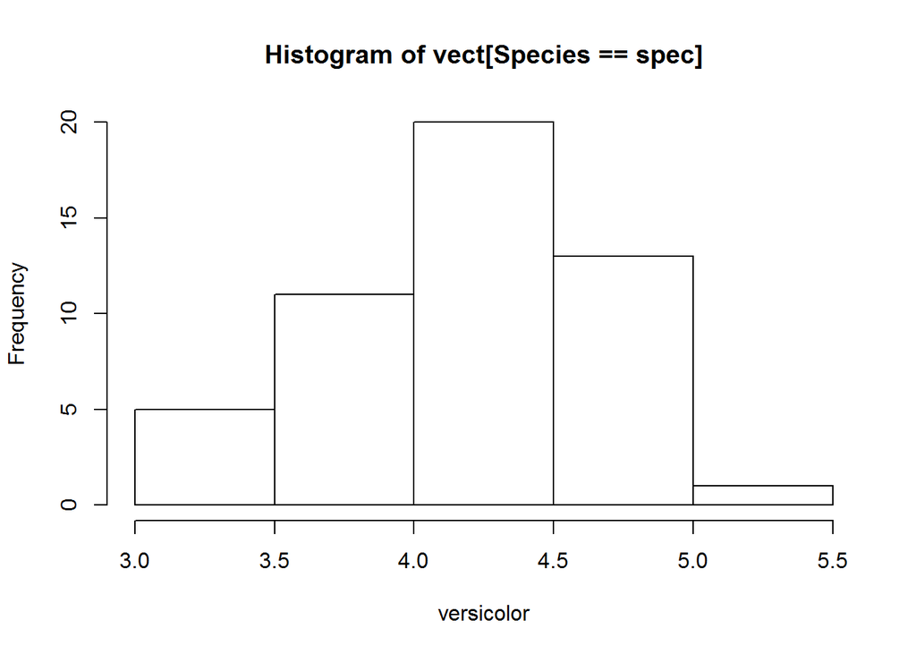

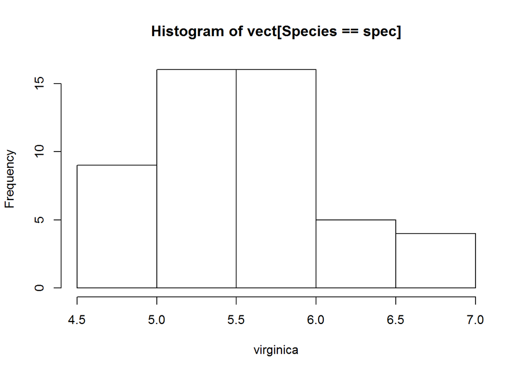

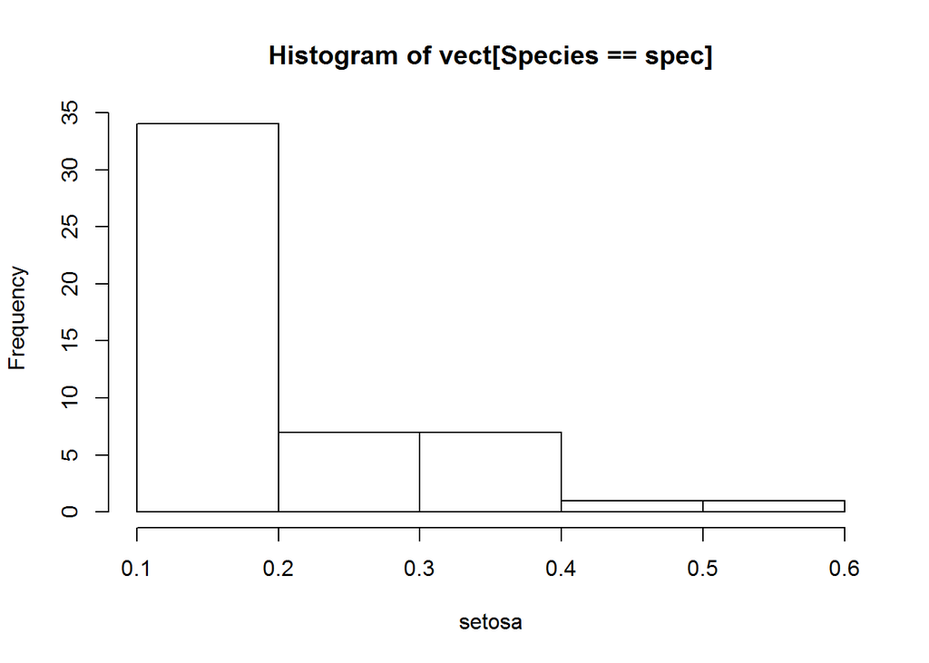

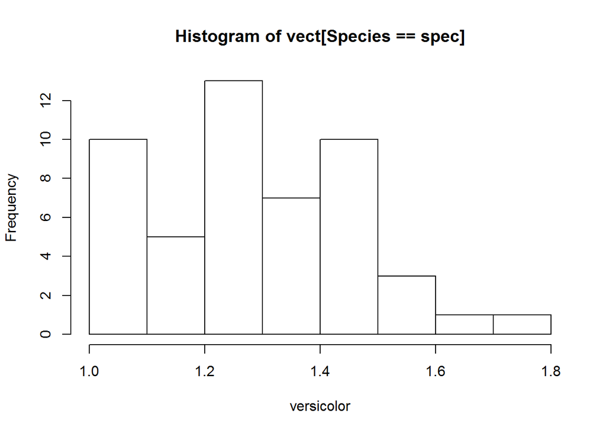

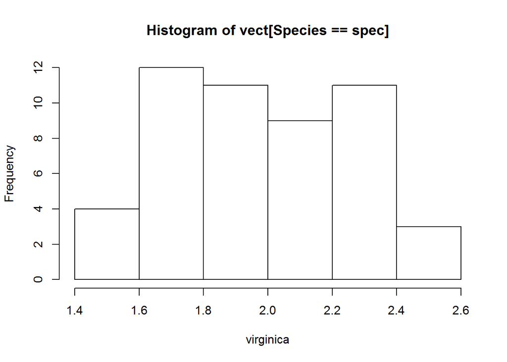

```r
for(j in 1:4){
  for(spec in levels(Species)){
    vect=iris[,j]
    hist(vect[Species==spec],xlab=spec)
  }
}
```